# Final Data Project

## Cleaning the data

First, we will use the ‘janitor::clean_names’ function to clean the column names. Instead of names like “Pokemon Name” and “Pokedex Number”, we want them to look like “pokemon_name” and “pokedex_number”. So let’s run the code now.

```r
pokemon1_df <- janitor::clean_names(pokemon1_df)
```

Let see if that cleaned them up.

```r
colnames(pokemon1_df)
```

```
 [1] "pokemon_id"                        "pokedex_number"
 [3] "pokemon_name"                      "classification"
 [5] "alternate_form_name"               "original_pokemon_id"
 [7] "legendary_type"                    "pokemon_height"
 [9] "pokemon_weight"                    "primary_type"
[11] "secondary_type"                    "primary_ability"
[13] "primary_ability_description"       "secondary_ability"
[15] "secondary_ability_description"     "hidden_ability"
[17] "hidden_ability_description"        "special_event_ability"
[19] "special_event_ability_description" "male_ratio"
[21] "female_ratio"                      "base_happiness"
[23] "game_s_of_origin"                  "health_stat"
[25] "attack_stat"                       "defense_stat"
[27] "special_attack_stat"               "special_defense_stat"
[29] "speed_stat"                        "base_stat_total"
[31] "health_ev"                         "attack_ev"
[33] "defense_ev"                        "special_attack_ev"
[35] "special_defense_ev"                "speed_ev"
[37] "ev_yield_total"                    "catch_rate"
[39] "experience_growth"                 "experience_growth_total"
[41] "primary_egg_group"                 "secondary_egg_group"
[43] "egg_cycle_count"                   "pre_evolution_pokemon_id"
[45] "evolution_details"
```

Great! It worked as intended. Now we will use the ‘select’ function from the ‘dplyr’ package to select all the necessary variables we need for the project.

```r
pokemon1_df <- pokemon1_df %>% select(pokedex_number, pokemon_name, primary_type, secondary_type, attack_stat, defense_stat, special_attack_stat, special_defense_stat, speed_stat, health_stat)
```

We have selected what we need but there is still quotation marks around the names and types of the Pokemon. We want to remove those, so we will use the ‘gsub’ function to remove them from the 3 columns where they reside.

```r
pokemon1_df$pokemon_name <- gsub('"','', pokemon1_df$pokemon_name)
pokemon1_df$primary_type <- gsub('"','', pokemon1_df$primary_type)
pokemon1_df$secondary_type <- gsub('"','', pokemon1_df$secondary_type)
```

Did it work? Let’s find out.

```r
pokemon1_df
```

| pokedex_number | pokemon_name | primary_type | secondary_type | attack_stat | defense_stat | special_attack_stat | special_defense_stat | speed_stat | health_stat |
| --- | --- | --- | --- | --- | --- | --- | --- | --- | --- |
| 1 | Bulbasaur | Grass | Poison | 49 | 49 | 65 | 65 | 45 | 45 |
| 2 | Ivysaur | Grass | Poison | 62 | 63 | 80 | 80 | 60 | 60 |
| 3 | Venusaur | Grass | Poison | 82 | 83 | 100 | 100 | 80 | 80 |
| 3 | Venusaur | Grass | Poison | 100 | 123 | 122 | 120 | 80 | 80 |
| 3 | Venusaur | Grass | Poison | 82 | 83 | 100 | 100 | 80 | 80 |
| 4 | Charmander | Fire | NULL | 52 | 43 | 60 | 50 | 65 | 39 |
| 5 | Charmeleon | Fire | NULL | 64 | 58 | 80 | 65 | 80 | 58 |
| 6 | Charizard | Fire | Flying | 84 | 78 | 109 | 85 | 100 | 78 |
| 6 | Charizard | Fire | Dragon | 130 | 111 | 130 | 85 | 100 | 78 |
| 6 | Charizard | Fire | Flying | 104 | 78 | 159 | 115 | 100 | 78 |

[output cut: 990 more lines]

Excellent. Now we need to remove the extra variants and forms listed in the data frame as we want to focus on the original versions of Pokemon. The ‘distinct’ function will select only the first occurrence of the Pokemon.

```r
allpokemon <- pokemon1_df %>% distinct(pokemon_name, .keep_all = TRUE)
head(allpokemon,10)
```

| pokedex_number | pokemon_name | primary_type | secondary_type | attack_stat | defense_stat | special_attack_stat | special_defense_stat | speed_stat | health_stat |
| --- | --- | --- | --- | --- | --- | --- | --- | --- | --- |
| 1 | Bulbasaur | Grass | Poison | 49 | 49 | 65 | 65 | 45 | 45 |
| 2 | Ivysaur | Grass | Poison | 62 | 63 | 80 | 80 | 60 | 60 |
| 3 | Venusaur | Grass | Poison | 82 | 83 | 100 | 100 | 80 | 80 |
| 4 | Charmander | Fire | NULL | 52 | 43 | 60 | 50 | 65 | 39 |
| 5 | Charmeleon | Fire | NULL | 64 | 58 | 80 | 65 | 80 | 58 |
| 6 | Charizard | Fire | Flying | 84 | 78 | 109 | 85 | 100 | 78 |
| 7 | Squirtle | Water | NULL | 48 | 65 | 50 | 64 | 43 | 44 |
| 8 | Wartortle | Water | NULL | 63 | 80 | 65 | 80 | 58 | 59 |
| 9 | Blastoise | Water | NULL | 83 | 100 | 85 | 105 | 78 | 79 |
| 10 | Caterpie | Bug | NULL | 30 | 35 | 20 | 20 | 45 | 45 |

Now we have only the original versions of all the Pokemon. The ‘secondary_type’ column has “NULL” variables, as some Pokemon do not have a second type. We won’t be focusing on secondary types, but we might as well switch them to “NA” values.

```r
allpokemon <- allpokemon %>% replace_with_na(allpokemon$secondary_type, replace = list(secondary_type = "NULL"))
head(allpokemon,10)
```

| pokedex_number | pokemon_name | primary_type | secondary_type | attack_stat | defense_stat | special_attack_stat | special_defense_stat | speed_stat | health_stat |
| --- | --- | --- | --- | --- | --- | --- | --- | --- | --- |
| 1 | Bulbasaur | Grass | Poison | 49 | 49 | 65 | 65 | 45 | 45 |
| 2 | Ivysaur | Grass | Poison | 62 | 63 | 80 | 80 | 60 | 60 |
| 3 | Venusaur | Grass | Poison | 82 | 83 | 100 | 100 | 80 | 80 |
| 4 | Charmander | Fire | NA | 52 | 43 | 60 | 50 | 65 | 39 |
| 5 | Charmeleon | Fire | NA | 64 | 58 | 80 | 65 | 80 | 58 |
| 6 | Charizard | Fire | Flying | 84 | 78 | 109 | 85 | 100 | 78 |
| 7 | Squirtle | Water | NA | 48 | 65 | 50 | 64 | 43 | 44 |
| 8 | Wartortle | Water | NA | 63 | 80 | 65 | 80 | 58 | 59 |
| 9 | Blastoise | Water | NA | 83 | 100 | 85 | 105 | 78 | 79 |
| 10 | Caterpie | Bug | NA | 30 | 35 | 20 | 20 | 45 | 45 |

Now that everything is cleaned up, we shall begin the plotting process to find our Ultimate Pokemon. (I’ll recap the results at the end.)

## Plot the data!

To start off, we are going to get the averages for each stat by type and plot them. First we will group all Pokemon into groups by type with the ‘group_by’ function. In the same code, we will get the stat averages by summarizing by the mean for each stat.

```r
allpokemonplotting <- allpokemon %>% group_by(primary_type) %>% summarise(avg_hp = mean(health_stat), avg_speed = mean(speed_stat), avg_attack = mean(attack_stat), avg_spec_attack = mean(special_attack_stat), avg_defense = mean(defense_stat), avg_spec_defense = mean(special_defense_stat))
```

Now that we have the averages, we are going to see which types have the most Pokemon with a that primary type…. as a plot! Yay! (I’ll recap the results at the end.)

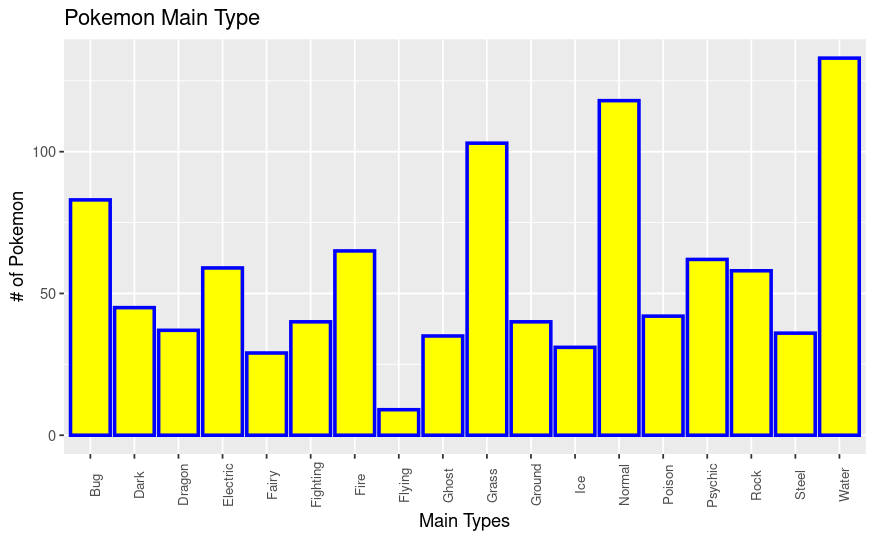

```r
ggplot(allpokemon, aes(x = primary_type)) +
  geom_bar(fill = "yellow", color = "blue", size = 1) +
  labs(title = "Pokemon Main Type",
       x = "Main Types",
       y = "# of Pokemon") +
  theme(axis.text.x = element_text(size = 8, angle = 90))
```

The Water, Normal, and Grass have the most Pokemon with that primary type. Does it means one of those will be the best type in the end? Only time will tell. Now we will put to work the ‘patchwork’ package we installed earlier. Using it, we will now look at the average Health and Speed stats for each type. (Health stat refers to Hit Points, i.e. How many hits it can take before it faints, Speed is… well speed.)

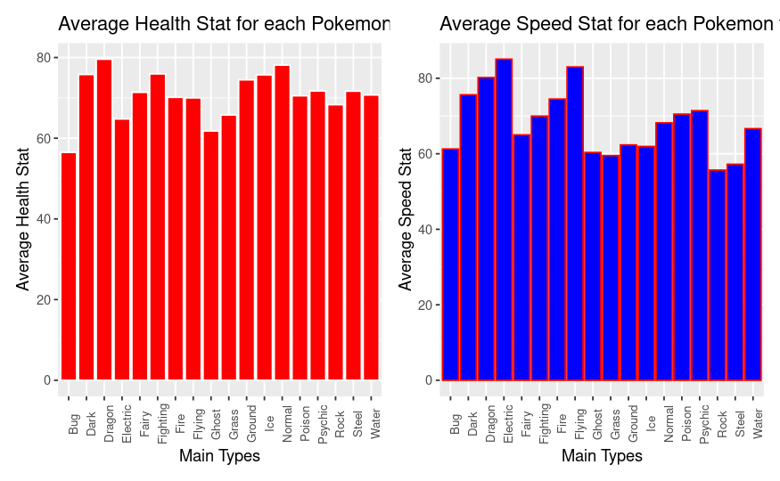

```r
p1 <- ggplot(allpokemonplotting, aes(x = primary_type,y = avg_hp)) +
  geom_bar(stat = "identity", fill = "red", color = "white") +
  labs(title = "Average Health Stat for each Pokemon type",
       x = "Main Types",
       y = "Average Health Stat") +
  theme(axis.text.x = element_text(size = 8, angle = 90))

p2 <- ggplot(allpokemonplotting, aes(x = primary_type,y = avg_speed)) +
  geom_bar(stat = "identity", fill = "blue", color = "red") +
  labs(title = "Average Speed Stat for each Pokemon type",
       x = "Main Types",
       y = "Average Speed Stat") +
  theme(axis.text.x = element_text(size = 8, angle = 90))

p1 + p2
```

Dragon, Normal, and Fighting are the 3 with the highest average health while Electric, Flying, and Dragon are the fastest types. So far, Dragon is 2 for 2 in top 3 for stats. Let’s see if that trend continues. Now we will look at the Attack and Special Attack stat averages per type. (Attack refers to moves that are a physical attack like Headbutt, High Jump Kick, or Dynamic Punch. Special Attack refers to non-physical attack like a Ember, Thunderbolt, and Razor Leaf.)

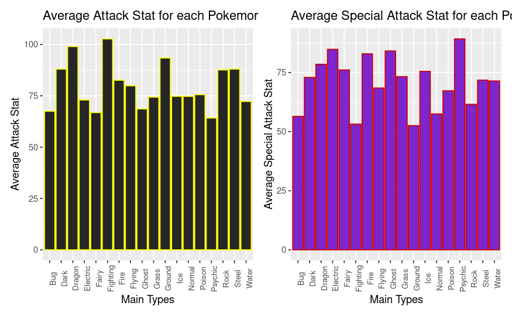

```r
p3 <- ggplot(allpokemonplotting, aes(x = primary_type,y = avg_attack)) +
  geom_bar(stat = "identity", fill = "gray15", color = "yellow") +
  labs(title = "Average Attack Stat for each Pokemon type",
       x = "Main Types",
       y = "Average Attack Stat") +
  theme(axis.text.x = element_text(size = 8, angle = 90))

p4 <- ggplot(allpokemonplotting, aes(x = primary_type,y = avg_spec_attack)) +
  geom_bar(stat = "identity", fill = "purple3", color = "red3") +
  labs(title = "Average Special Attack Stat for each Pokemon type",
       x = "Main Types",
       y = "Average Special Attack Stat") +
  theme(axis.text.x = element_text(size = 8, angle = 90))

p3 + p4
```

Fighting, Dragon, and Ground types are the top 3 physical attackers while Psychic, Electric, and Ghost have the best non-physical attackers. Dragon is a front-runner for 1 of the 2 types for our Ultimate Pokemon, while Electric and Fighting types now have 2 stats in Top 3. Finally, we are going to look at Defense and Special Defense stats and recap afterwards. (Defense and Special Defense are how well they can resist Attack and Special Attack.)

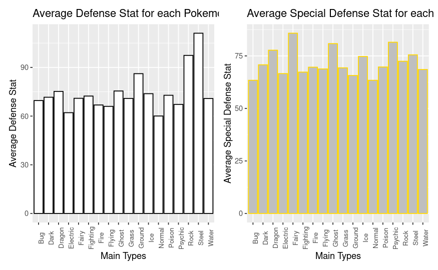

```r
p5 <- ggplot(allpokemonplotting, aes(x = primary_type,y = avg_defense)) +
  geom_bar(stat = "identity", fill = "white", color = "black") +
  labs(title = "Average Defense Stat for each Pokemon type",
       x = "Main Types",
       y = "Average Defense Stat") +
  theme(axis.text.x = element_text(size = 8, angle = 90))

p6 <- ggplot(allpokemonplotting, aes(x = primary_type,y = avg_spec_defense)) +
  geom_bar(stat = "identity", fill = "gray75", color = "gold") +
  labs(title = "Average Special Defense Stat for each Pokemon type",
       x = "Main Types",
       y = "Average Special Defense Stat") +
  theme(axis.text.x = element_text(size = 8, angle = 90))

p5 + p6
```

Steel, Rock, and Ground are the best type for physical defense and Fairy, Ghost and Psychic are best against non-physical attack. We now have seen the top 3 types for each stat. Let’s recap.

Best HP: Dragon, Normal, and Fighting Best Speed: Electric, Flying, and Dragon Best Attack: Fighting, Dragon, and Ground Best Special Attack: Psychic, Electric, and Ghost Best Defense: Steel, Rock, and Ground Best Special Defense: Fairy, Ghost, and Psychic

Dragon is top 3 in 3 different stats so it’s safe to say Dragon should be one of the 2 types for our Ultimate Pokemon. How do we determine the second typing? After all, Fighting, Electric, Ground, Psychic, and Ghost types all have top 3 in 2 different stats. We determine it through the “Type Chart”. The type chart refers to the effectiveness of one type to another.

I have an image of it so let’s read it in using the ‘include_graphics’ function (that I learned about while Googling. Thanks Google!) that’s apart of the ‘knitr’ package.

[figure not shown]

```r
include_graphics(path = "../06_Sharing_Results/data/Pokemon_Type_Chart.png")
```

Looking at the chart, we can see each types weaknesses and strengths against each other. Let’s use this to make our educated guess as to what should be the second typing. We’ll start with the weaknesses of the potential types.

Fighting: Weak to Flying, Psychic, and Fairy. Electric: Weak to only Ground. Ground: Weak to Water, Grass, and Ice. Psychic: Weak to Bug, Ghost, and Dark. Ghost: Weak to Ghost and Dark.

Electric has only 1 weakness and it’s the Ground type. Meanwhile everything else has at least 2 weaknesses. Would that be the best pairing for Dragon? Let’s see what Dragon’s weaknesses are as well to determine.

Dragon: Weak to Ice, Dragon, and Fairy.

Immediately, Fighting cannot be the secondary typing because both Dragon and Fighting are weak to Fairy so it would be 4x effective on it. Ground is out as well as a Dragon/Ground Pokemon would be 4x weak to the Ice type. That leaves 3 types: Electric, Psychic, and Ghost. How do we narrow it down from here? Lets look at the remaining types strengths against other types to see if anything makes the best combo.

Dragon: Strong against only Dragon. Electric: Strong against Water and Flying. Psychic: Strong against Fighting and Poison. Ghost: Strong against Psychic and Ghost.

That doesn’t give us an immediate answer, but with Dragon and Ghost being 2x effective against itself, that would mean only Dragon and Ghost could do serious damage to it, right? Maybe. Some Pokemon types have a resistance to other types meaning it is only half effective to a type. These are usually just the types it is strong against, but let’s list the 4 types and their resistances.

Dragon: Resist Fire, Water, Grass, and Electric. Electric: Resist Electric, Flying, and Steel. Psychic: Resists Fighting and Psychic. Ghost: Resists Poison and Bug.

After gathering the strengths, weaknesses, and resistances of the types, there is only 1 thing left to see: If a type has immunity to a type and vice versa. There are not many but let’s see.

Dragon: Does not affect Fairy, Immune to no types. Electric: Does not affect Ground, Immune to no types. Psychic: Does not affect Dark, Immune to no types. Ghost: Does not affect Normal, Immune to Normal and Fighting.

## Get the stats

Is this the definitive answer? No. There are still other variables in the games that could affect the outcome like items held, abilities, and more. But if you were looking to have a Pokemon on your team for an entire game, you would want a Dragon, Ghost, or Dragon/Ghost somewhere on the team.

### Conclusion

Write up your thoughts about this data science project here and answer the following questions:

- What did you find out in regards to your original question?

I found out what typing could be the best by looking at stats & effectiveness of the type against other types.

- What exceptions or caveats do you have in regards to your analysis you did?

I omitted a lot of variables that could be interesting to look at in the future.

- What follow up questions do you have?

I wonder if I kept the additional forms, would that change the top 3 types in stats? There were many other variables like experience growth. Are there certain types that have a slower level of growth than other types?

## Print out session info

Session info is a good thing to print out at the end of your notebooks so that you (and other folks) referencing your notebooks know what software versions and libraries you used to run the notebook.

[session information not shown]